# hw2

yang an

2024-10-20

Homework 2 ## question

###1. ####answer: (a) Illustrate a data set

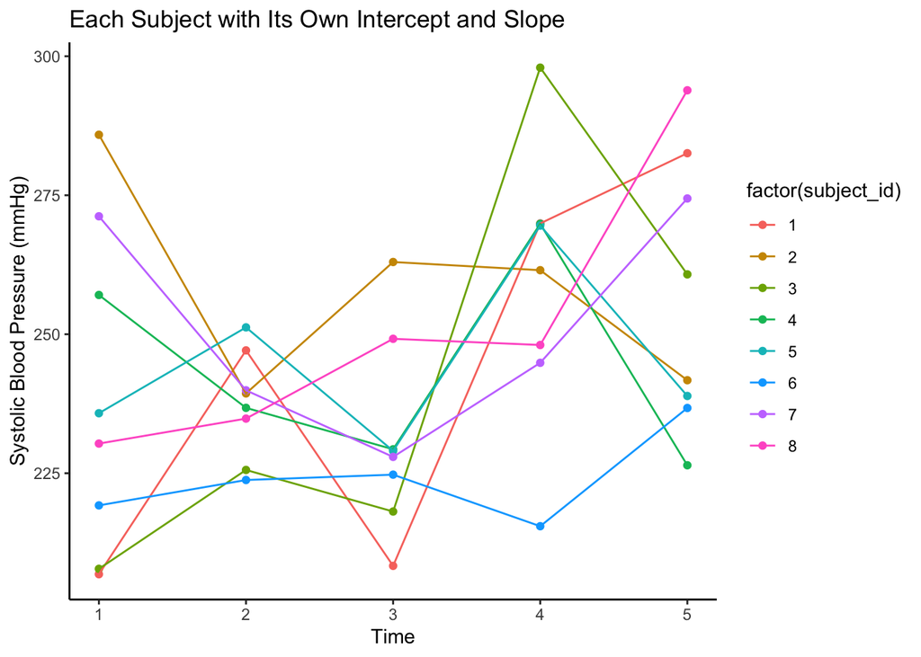

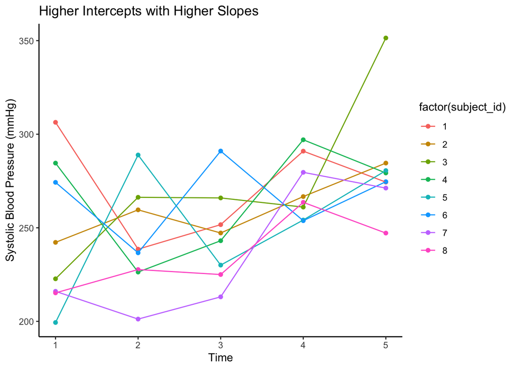

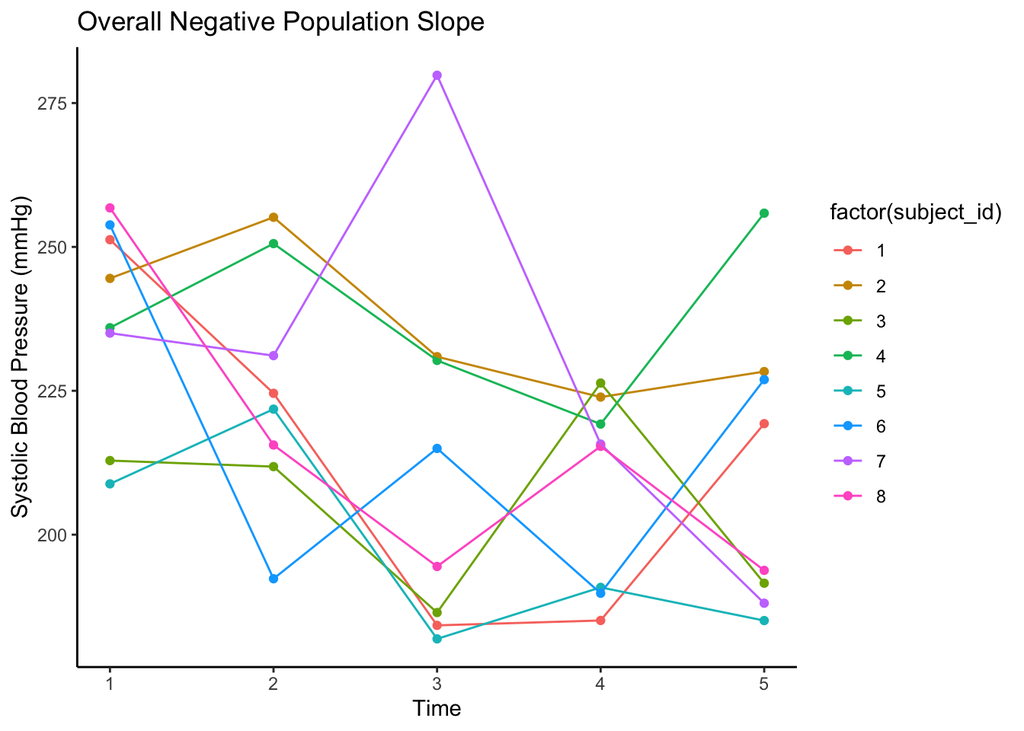

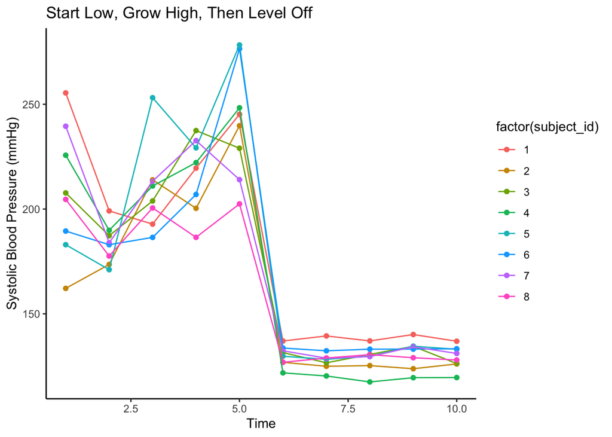

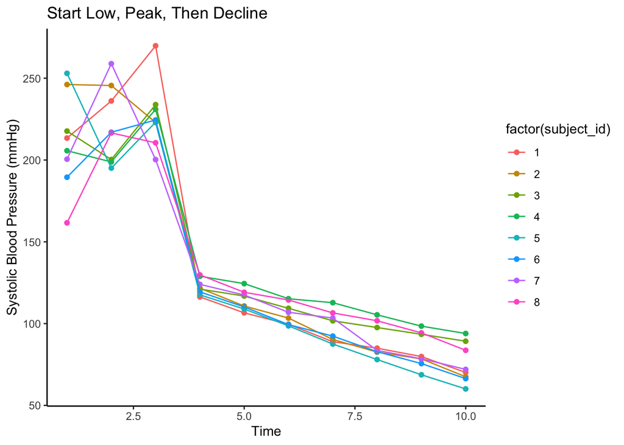

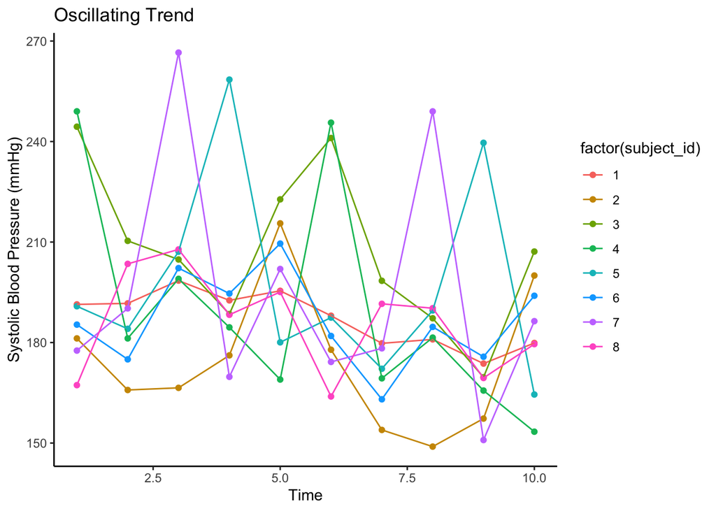

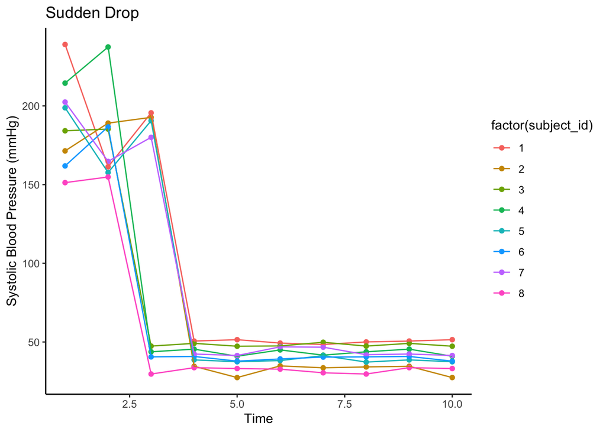

sentence: The first pattern shows a sinusoidal oscillation over time, while the second pattern shows an a sudden drop in the data.

2. Chapter 3, problem 7

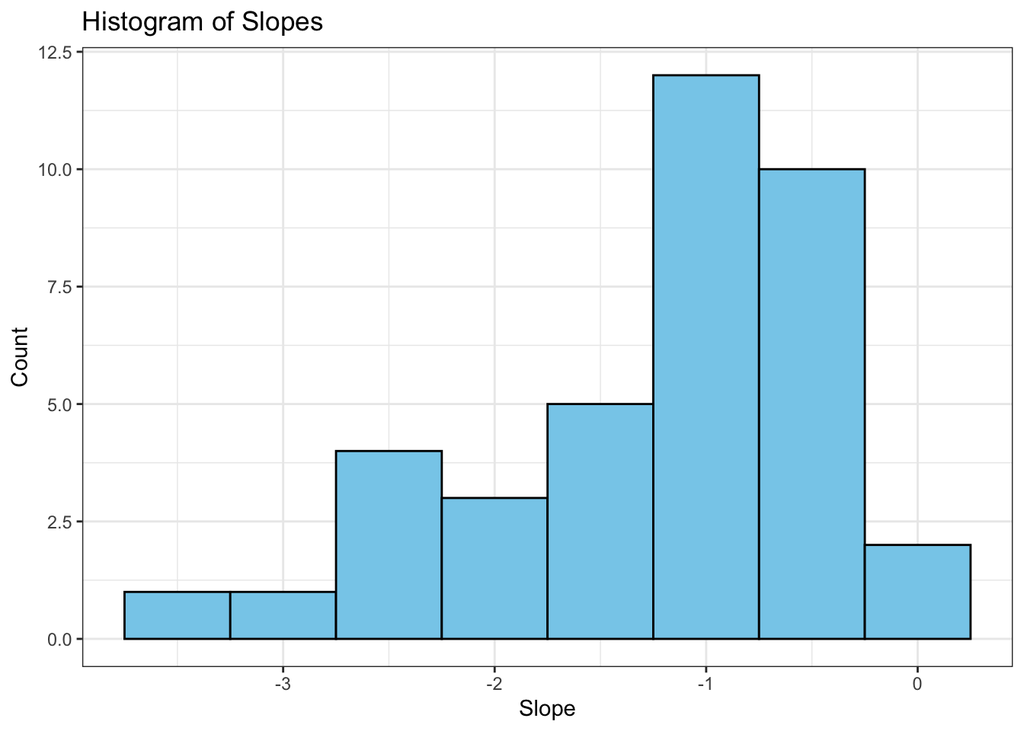

```r
library(dplyr)
library(readr)
library(ggplot2)

# Load the weight loss data
setwd('/Users/yangan/Desktop/M236/M236-Lab/hw2')

options(scipen = 999)

weight_loss_data_in <- read_tsv("Weight Loss Version1(weekly observations).txt", col_names = TRUE)
weight_loss_data <- weight_loss_data_in[complete.cases(weight_loss_data_in),]

# Calculate slopes for each subject
slopes <- weight_loss_data %>%
  group_by(id) %>%
  summarize(slope = lm(weight ~ week)$coefficients[2])

# Plot the slopes in a histogram
ggplot(data = slopes) +
  geom_histogram(aes(x = slope), binwidth = 0.5, fill = "skyblue", color = "black") +
  theme_bw() +
  labs(x = "Slope",
       y = "Count",
       title = "Histogram of Slopes")
```

```r
# Calculate the average slope
mean_slope <- mean(slopes$slope)

# Calculate the standard deviation of the slopes
sd_slope <- sd(slopes$slope)

mean_slope
```

```
## [1] -1.234484
```

```r
sd_slope
```

```
## [1] 0.8376076
```

```r
# Perform a t-test to test if the average slope is equal to zero
t_test <- t.test(slopes$slope, mu = 0)

t_test
```

```
##
##  One Sample t-test
##
## data:  slopes$slope
## t = -9.0852, df = 37, p-value = 0.00000000005863
## alternative hypothesis: true mean is not equal to 0
## 95 percent confidence interval:
##  -1.5097992 -0.9591696
## sample estimates:
## mean of x
## -1.234484
```

```r
# Select subjects with varying amounts of data
subject_1 <- filter(weight_loss_data, id == 1)
subject_2 <- filter(weight_loss_data, id == 2)

# Perform linear regression for each subject
lm_1 <- lm(weight ~ week, data = subject_1)
lm_2 <- lm(weight ~ week, data = subject_2)

# Extract standard errors of the slopes
se_1 <- summary(lm_1)$coefficients[2, 2]
se_2 <- summary(lm_2)$coefficients[2, 2]

# Compare standard errors
se_1
```

```
## [1] 0.5660371
```

```r
se_2
```

```
## [1] 0.2523864
```

```r
slope_1 <- lm(weight ~ week, data = subject_1)$coefficients[2]
slope_2 <- lm(weight ~ week, data = subject_2)$coefficients[2]

slope_1
```

```
##       week
## -0.3928571
```

```r
slope_2
```

```
##       week
## -0.7139344
```

```r
# Perform a t-test to test if the average slope is equal to zero
t_test <- t.test(slopes$slope, mu = 0)

t_test
```

```
##
##  One Sample t-test
##
## data:  slopes$slope
## t = -9.0852, df = 37, p-value = 0.00000000005863
## alternative hypothesis: true mean is not equal to 0
## 95 percent confidence interval:
##  -1.5097992 -0.9591696
## sample estimates:
## mean of x
## -1.234484
```

There are more fluctuations of weight in subject 1 than in subject 2. The standard errors of the slopes are different for the two subjects, with subject 1 having a higher standard error than subject 2. A t-test assumes that the data is normally distributed and that the variances are similar across observations. The t-test analysis may not be appropriate for comparing this, as the standard errors vary significantly between subjects and there are outliers which affect validity.

The slope may not be an appropriate summary of an individual’s weight loss because it only captures the rate of change over time and does not account for other factors that may influence weight loss, such as diet, exercise, and metabolism. Additionally, weight loss is not always linear and has some outliers. Other summary measures, such as the total weight loss over a specific period or the percentage of body weight lost, may provide a more comprehensive and accurate summary of an individual’s weight loss progress.

3. Chapter 3, problem 8

```r
# Load necessary libraries
library(dplyr)

# Read the data
ozone_data_in <- read.table("Ozone data.txt", header = TRUE)
ozone_data <- ozone_data_in[complete.cases(ozone_data_in),]
# Group data by 'site' and calculate the first, last ozone values and the difference
ozone_summary <- ozone_data %>%
  dplyr::group_by(fullname) %>%
  dplyr::summarise(first = first(ozone),
            last = last(ozone),
            diff = last - first,
            mean = mean(ozone),
            range = max(ozone) - min(ozone))

# Print the results
print(head(ozone_summary, 10))
```

```
## # A tibble: 10 × 6
##    fullname               first  last  diff  mean range
##    <chr>                  <dbl> <dbl> <dbl> <dbl> <dbl>
##  1 ANAHEIM                  1     4     3    5.86  11
##  2 AZUSA                    3     9     6    9.14  23
##  3 BURBANK                  0     2     2    6.58  17
##  4 CLAREMONT-COLLEGE        0.3  12.4  12.1 11.9   28.4
##  5 FONTANA-ARROW-HIGHWAY    0    13    13    9.97  23
##  6 HAWTHORNE                0     3     3    3.5    6
##  7 LA-HABRA                 0     5     5    7.08  14
##  8 LOS-ANGELES-NORTH-MAIN   0     3     3    5.03  11
##  9 LYNWOOD                  1     3     2    3.83   6
## 10 NORTH-LONG-BEACH         1     4     3    3.5    7
```

The Ozone data could be summarized by a difference di equal to the last observation minus the first observation. However, the difference in ozone levels may not be the best summary measure as it does not account for the overall trend or variability in ozone levels over time. A better summary measure might be the mean ozone level or the range of ozone levels, as these measures provide more information about the central tendency and spread of the data, respectively.

4. Problem 2, chapter 4

```r
# Load necessary libraries
library(tidyr)
library(dplyr)

# Recreate the dataset in wide format
data <- data.frame(
  Subject = 1:20,
  Week_0 = c(219, 167, 152, 194, 235, 200, 181, 211, 250, 210, 142, 192, 217, 187, 188, 187, 184, 197, 200, 219),
  Week_2 = c(222, 161, 144, 193, 231, 199, 183, 204, 249, 209, 140, 195, 217, 189, 196, 191, 189, 201, 205, 223),
  Week_4 = c(221, 165, 144, 193, 235, 195, 177, 210, 247, 209, 143, 193, 220, 189, 194, 187, 184, 200, 205, 225),
  Week_6 = c(215, 161, 147, 189, 236, 199, 175, 208, 251, 212, 142, 193, 219, 193, 191, 187, 188, 198, 206, 222),
  Week_8 = c(214, 158, 145, 191, 235, 195, 180, 211, 251, 212, 147, 198, 224, 195, 193, 181, 189, 201, 209, 226),
  Week_10 = c(211, 159, 146, 189, 231, 197, 180, 211, 250, 213, 144, 201, 226, 202, 191, 179, 189, 204, 210, 231)
)
```

```r
# Convert wide format to long format
data_long = data %>%
  pivot_longer(cols = starts_with('Week'),
               names_to = 'Week',
               values_to = 'Weight') %>%
  mutate(Week = as.numeric(gsub('Week_', '', Week))) # Extract numerical values from Week names

head(data_long, 10)
```

```
## # A tibble: 10 × 3
##    Subject  Week Weight
##      <int> <dbl>  <dbl>
##  1       1     0    219
##  2       1     2    222
##  3       1     4    221
##  4       1     6    215
##  5       1     8    214
##  6       1    10    211
##  7       2     0    167
##  8       2     2    161
##  9       2     4    165
## 10       2     6    161
```

```r
# Perform a paired t-test using the weight at week 10 and the baseline weight for all 20 subjects
week_10 <- data_long %>%
  filter(Week == 10) %>%
  select(Weight) %>%
  pull()

baseline <- data_long %>%
  filter(Week == 0) %>%
  select(Weight) %>%
  pull()

t.test(week_10, baseline, paired = TRUE)
```

```
##
##  Paired t-test
##
## data:  week_10 and baseline
## t = 1.0094, df = 19, p-value = 0.3255
## alternative hypothesis: true mean difference is not equal to 0
## 95 percent confidence interval:
##  -1.717712  4.917712
## sample estimates:
## mean difference
##             1.6
```

p-value = 0.3255, which is not significant at the 0.05 level. Therefore, we fail to reject the null hypothesis that there is no difference in weight between week 10 and baseline for all 20 subjects.

```r
# Filter out subjects with bold observations
complete_subjects <- data_long %>%
  filter(!(Subject %in% c(11, 12, 13, 14, 15, 16, 17, 18, 19, 20)))

week_10_complete <- complete_subjects %>%
  filter(Week == 10) %>%
  select(Weight) %>%
  pull()

baseline_complete <- complete_subjects %>%
  filter(Week == 0) %>%
  select(Weight) %>%
  pull()

t.test(week_10_complete, baseline_complete, paired = TRUE)
```

```
##
##  Paired t-test
##
## data:  week_10_complete and baseline_complete
## t = -2.753, df = 9, p-value = 0.02237
## alternative hypothesis: true mean difference is not equal to 0
## 95 percent confidence interval:
##  -5.8294705 -0.5705295
## sample estimates:
## mean difference
##            -3.2
```

p_value = 0.02237, which is significant at the 0.05 level. Therefore, we reject the null hypothesis, and conclude that there is a significant difference in weight between week 10 and baseline for the 10 complete observations.

```r
# Use the last regular (non-bold) observation for subjects with at least two observations
last_observation <- data_long %>%
  group_by(Subject) %>%
  filter(n() >= 2) %>%  # Ensure each subject has at least two observations
  summarize(last_weight = ifelse(any(Weight >= Weight[Week == 0] + 4),
                                 max(Weight[Week < min(Week[Weight >= Weight[Week == 0] + 4])]), # Last regular weight before bold
                                 max(Weight[Week == 10]))) # For subjects with no bold, use Week 10

baseline <- data_long %>%
  filter(Week == 0) %>%
  select(Subject, Weight) %>%
  pull()

last_weights <- last_observation$last_weight

# Paired t-test between the last regular observation and baseline (Week 0)
t.test(last_weights, baseline, paired = TRUE)
```

```
##
##  Paired t-test
##
## data:  last_weights and baseline
## t = -1.5095, df = 19, p-value = 0.1476
## alternative hypothesis: true mean difference is not equal to 0
## 95 percent confidence interval:
##  -2.744542  0.444542
## sample estimates:
## mean difference
##           -1.15
```

p_value = 0.1476, which is not significant at the 0.05 level. Therefore, we fail to reject the null hypothesis, and conclude that there is no significant difference in weight between the last regular observation and baseline for subjects with at least two observations.

```r
# Use the last observation before dropout
before_dropout <- data_long %>%
  group_by(Subject) %>%
  summarize(last_weight = ifelse(any(Weight >= Weight[Week == 0] + 4),
                                 max(Weight[Week == max(Week[Weight < Weight[Week == 0] + 4])]), # Last weight before bold (dropout)
                                 max(Weight[Week == 10]))) # For subjects with no bold, use Week 10

baseline <- data_long %>%
  filter(Week == 0) %>%
  select(Subject, Weight) %>%
  pull()

last_weights_dropout <- before_dropout$last_weight

# Paired t-test between last available observation before dropout and baseline (Week 0)
t.test(last_weights_dropout, baseline, paired = TRUE)
```

```
##
##  Paired t-test
##
## data:  last_weights_dropout and baseline
## t = -1.498, df = 19, p-value = 0.1506
## alternative hypothesis: true mean difference is not equal to 0
## 95 percent confidence interval:
##  -3.116424  0.516424
## sample estimates:
## mean difference
##            -1.3
```

p_value = 0.1506, which is not significant at the 0.05 level. Therefore, we fail to reject the null hypothesis, and conclude that there is no significant difference in weight between the last available observation before dropout and baseline for all subjects.

```r
# Compare the conclusions for the four t-tests
conclusions <- data.frame(
  Test = c('All 20 subjects', '10 complete observations', 'Last regular observation', 'Last observation before dropout'),
  p_value = c(0.3255, 0.02237, 0.1476, 0.1506),
  Conclusion = c('Fail to reject H0', 'Reject H0', 'Fail to reject H0', 'Fail to reject H0')
)

conclusions
```

```
##                              Test p_value        Conclusion
## 1                 All 20 subjects 0.32550 Fail to reject H0
## 2        10 complete observations 0.02237         Reject H0
## 3        Last regular observation 0.14760 Fail to reject H0
## 4 Last observation before dropout 0.15060 Fail to reject H0
```

```r
# Determine overall diet effectiveness
diet_effectiveness <- ifelse(any(conclusions$Conclusion == 'Reject H0'), 'Partially Effective', 'Not Effective')
diet_effectiveness
```

```
## [1] "Partially Effective"
```

```r
# Naive researcher's conclusion
naive_researcher <- ifelse(conclusions$Conclusion[2] == 'Reject H0', 'Reject H0', 'Fail to reject H0')
naive_researcher
```

```
## [1] "Reject H0"
```

```r
# Moral of the analysis
moral <- 'The conclusions depend on the subset of data used. It is critical to consider how dropout or missing data affects the results, as excluding these observations can create selection bias and lead to misleading interpretations.'
moral
```

```
## [1] "The conclusions depend on the subset of data used. It is critical to consider how dropout or missing data affects the results, as excluding these observations can create selection bias and lead to misleading interpretations."
```

For the subjects of weeks 10 and baseline, the p value is 0.3255>0.05, which is not significant at the 0.05 level. Therefore, we fail to reject the null hypothesis and conclude that there is no difference in weight between week 10 and baseline for all 20 subjects. For the 10 complete observations, the p value is 0.02237<0.05, which is significant at the 0.05 level. Therefore, we reject the null hypothesis and conclude that there is a significant difference in weight between week 10 and baseline for the 10 complete observations. For subjects with at least two observations, the p value is 0.1476>0.05, which is not significant at the 0.05 level. Therefore, we fail to reject the null hypothesis and conclude that there is no significant difference in weight between the last regular observation and baseline for subjects with at least two observations. For subjects who drop out just after the boldface observation, the p value is 0.1506>0.05, which is not significant at the 0.05 level. Therefore, we fail to reject the null hypothesis and conclude that there is no significant difference in weight between the last available observation before dropout and baseline for all subjects. The diet is effective based on the 10 complete observations, but not effective based on the last regular observation and last available observation before dropout. As a result, we can conclude that the diet is effective for those subjects who complete the study, but it could also be biased because those who drop out was excluded from the analysis. For the overall conclusion, the diet is not consistently effective across all analyses. A naive researcher might conclude that the diet is effective based on the 10 complete observations, but this conclusion would be misleading given the results from the other analyses. The moral of the analyses is that the conclusions drawn from the analyses depend on the subset of data usred for the analysis. It is important to consider the reasons for missing data and how they may affect the results and conclusions of the study.

```r
# Compare the last observation before dropout to Week 10 observation for each subject
comparison <- data_long %>%
  group_by(Subject) %>%
  # Identify the last weight before dropout (first bold observation)
  summarize(
    week_10 = max(Weight[Week == 10]),
    last_weight_before_dropout = ifelse(any(Weight >= Weight[Week == 0] + 4),
                                        max(Weight[Week < min(Week[Weight >= Weight[Week == 0] + 4])]), # Last weight before bold
                                        max(Weight[Week == 10])) # For subjects with no bold, use Week 10
  )

# Filter only subjects with bold observations (those who "dropped out")
dropout_subjects <- comparison %>%
  filter(week_10 != last_weight_before_dropout)

# Extract Week 10 and last observation before dropout
week_10_values <- dropout_subjects$week_10
last_before_dropout_values <- dropout_subjects$last_weight_before_dropout

# Paired t-test between Week 10 and the last observation before dropout
t_test_f <- t.test(week_10_values, last_before_dropout_values, paired = TRUE)
t_test_f
```

```
##
##  Paired t-test
##
## data:  week_10_values and last_before_dropout_values
## t = 2.8701, df = 9, p-value = 0.01847
## alternative hypothesis: true mean difference is not equal to 0
## 95 percent confidence interval:
##  1.165018 9.834982
## sample estimates:
## mean difference
##             5.5
```

```r
# Add a comparison column to see if Week 10 is always higher than the last weight before dropout
comparison <- comparison %>%
  mutate(is_week_10_higher = week_10 > last_weight_before_dropout)

comparison
```

```
## # A tibble: 20 × 4
##    Subject week_10 last_weight_before_dropout is_week_10_higher
##      <int>   <dbl>                      <dbl> <lgl>
##  1       1     211                        211 FALSE
##  2       2     159                        159 FALSE
##  3       3     146                        146 FALSE
##  4       4     189                        189 FALSE
##  5       5     231                        231 FALSE
##  6       6     197                        197 FALSE
##  7       7     180                        180 FALSE
##  8       8     211                        211 FALSE
##  9       9     250                        250 FALSE
## 10      10     213                        213 FALSE
## 11      11     144                        143 TRUE
## 12      12     201                        195 TRUE
## 13      13     226                        220 TRUE
## 14      14     202                        189 TRUE
## 15      15     191                        188 TRUE
## 16      16     179                        187 FALSE
## 17      17     189                        184 TRUE
## 18      18     204                        197 TRUE
## 19      19     210                        200 TRUE
## 20      20     231                        219 TRUE
```

The P_value is 0.01847, which is significant at the 0.05 level. Therefore, we reject the null hypothesis and conclude that there is a significant difference in weight between Week 10 and the last observation before dropout for subjects who drop out. The 10-week observation is not always higher than the last observation before dropout for subjects who drop out.

the DoD design is more robust to missing data and dropouts than the single sample paired t-test. In this example, the single sample paired t-test would not be able to handle the missing data from subjects who drop out, as it requires complete data for all subjects. The DoD design, on the other hand, allows for the analysis of subjects with incomplete data by comparing the last available observation before dropout to the baseline observation. This provides a more comprehensive analysis of the data and allows for a more accurate assessment of the effectiveness of the diet. Therefore, the DoD design is a more flexible and robust approach to handling missing data and dropouts in longitudinal studies.